# Time Series Project: Spring 2020

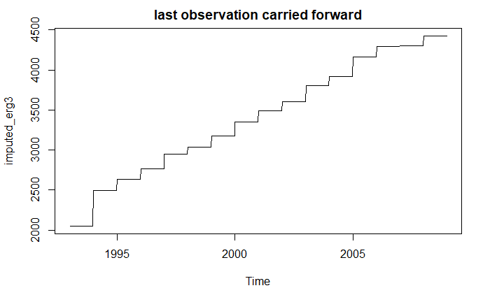

```r
plot(imputed_erg3, main =  'last observation carried forward')
```

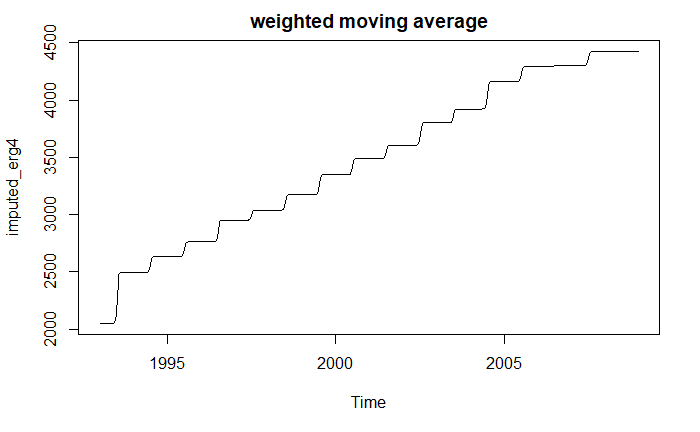

```r
plot(imputed_erg4, main = 'weighted moving average')
```

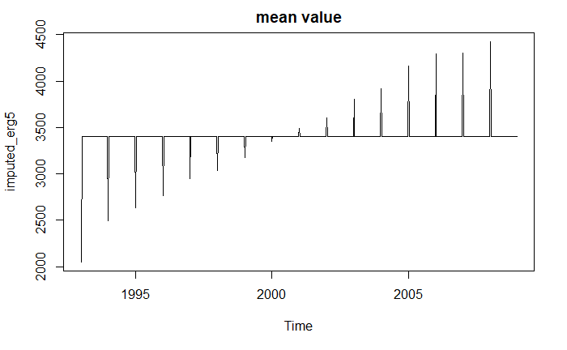

```r
plot(imputed_erg5, main = 'mean value')
```

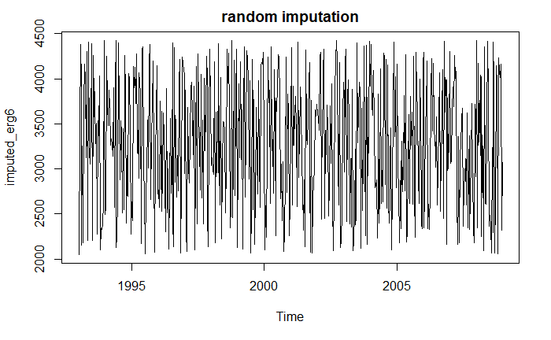

```r
plot(imputed_erg6, main = 'random imputation')
```

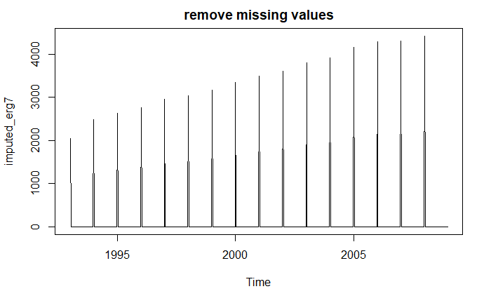

```r
plot(imputed_erg7, main = 'remove missing values')
```

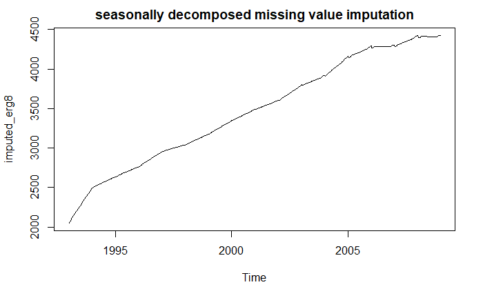

```r
plot(imputed_erg8, main = 'seasonally decomposed missing value imputation')
```

```r
#get global population data from https://data.worldbank.org/indicator/sp.pop.totl
pop = read.csv("D:/SMU/DS 6373 Time Series/API_SP.POP.TOTL_DS2_en_csv_v2_887275.csv")
```

contains population by country per year from 1960 to 2018 from worldbank, will use global population total

```r
tpop = as.data.frame(t(pop)) #transpose
gpop = tpop$V258 #world population column

global_pop = as.data.frame(gpop[5:(length(gpop)-1)], stringsAsFactors = FALSE)
global_pop = ts(as.numeric(as.character(global_pop[, 1])), start = 1960, frequency = 1)
#plot(global_pop)
global_pop_limited = global_pop[34:49]

#impute
trimonthly_imputation = vector()
#years = seq(1, length(global_pop$`gpop[5:(length(gpop) - 1)]`), 1)
year = seq(1, 16, 1) #limited overlap range for multivariate merge
for(q in year)
{
  trimonthly_imputation <- append(trimonthly_imputation, as.numeric(as.character(global_pop_limited[q])))
  #print(as.numeric(as.character(global_pop_limited[q])))
  trimonthly_imputation <- append(trimonthly_imputation, rep(NA, 35))
}

gpi = ts(trimonthly_imputation, start = 1993, frequency = 36) #empty ts for imputation
```

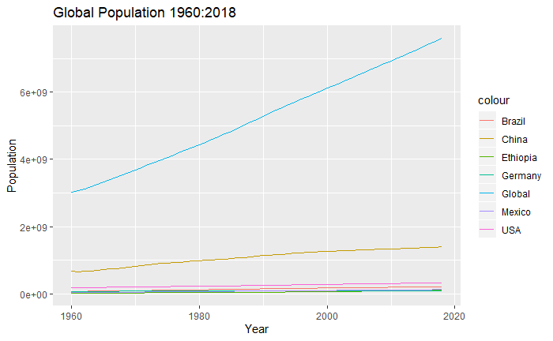

```r
#reg data
#plot(global_pop, main = "Global Population 1993:2018 ")
brazil_pop <- as.numeric(as.character(tpop$V28[5:63]))
usa_pop <- as.numeric(as.character(tpop$V250[5:63]))
china_pop <- as.numeric(as.character(tpop$V39[5:63]))
ethiopia_pop <- as.numeric(as.character(tpop$V71[5:63]))
germany_pop <- as.numeric(as.character(tpop$V54[5:63]))
india_pop <- as.numeric(as.character(tpop$V108[5:63]))
mexico_pop <- as.numeric(as.character(tpop$V153[5:63]))

gr_pop <- cbind(global_pop, brazil_pop, usa_pop, china_pop, india_pop, germany_pop, mexico_pop, ethiopia_pop)
ggplot() +
  geom_line(data = gr_pop[, 1], aes(x = seq(1960, 2018, 1), y = global_pop, color = "Global"))+
  geom_line(data = gr_pop[, 2], aes(x = seq(1960, 2018, 1), y = brazil_pop, color = "Brazil"))+
  geom_line(data = gr_pop[, 3], aes(x = seq(1960, 2018, 1), y = usa_pop, color = "USA"))+
  geom_line(data = gr_pop[, 4], aes(x = seq(1960, 2018, 1), y = china_pop, color = "China"))+
  geom_line(data = gr_pop[, 5], aes(x = seq(1960, 2018, 1), y = ethiopia_pop, color = "Ethiopia"))+
  geom_line(data = gr_pop[, 6], aes(x = seq(1960, 2018, 1), y = germany_pop, color = "Germany"))+
  geom_line(data = gr_pop[, 7], aes(x = seq(1960, 2018, 1), y = mexico_pop, color = "Mexico"))+
  ggtitle("Global Population 1960:2018")+
  xlab("Year")+
  ylab("Population")
```

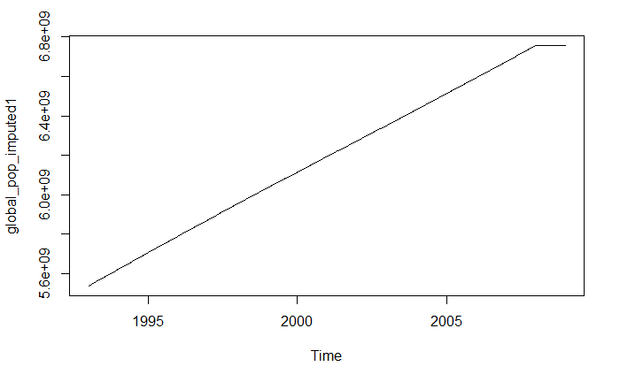

```r
#imputation options
global_pop_imputed1 = as.ts(na_interpolation(gpi, option = 'linear'), start = 1993, frequency = 36)
plot(global_pop_imputed1)
```

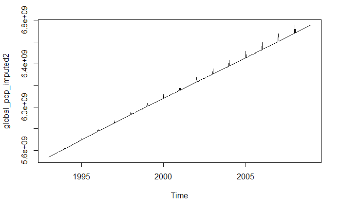

```r
global_pop_imputed2 = as.ts(na_interpolation(gpi, option = 'spline'), start = 1993, frequency = 36)
plot(global_pop_imputed2)
```

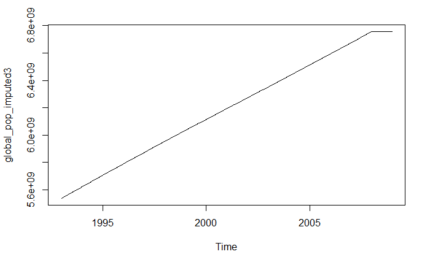

```r
global_pop_imputed3 = as.ts(na_interpolation(gpi, option = 'stine'), start = 1993, frequency = 36)
plot(global_pop_imputed3)
```

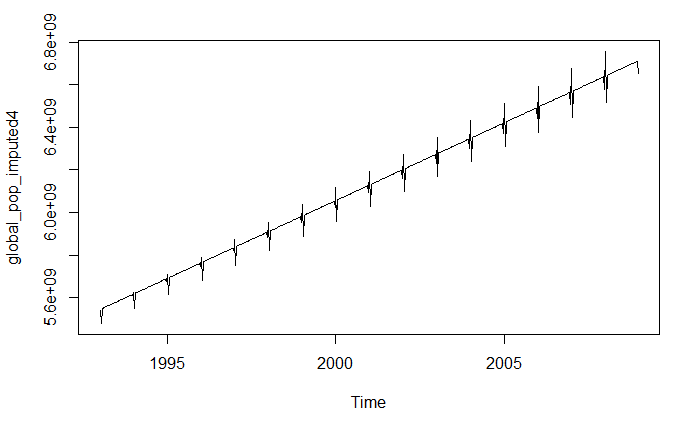

```r
global_pop_imputed4 = as.ts(na_kalman(gpi), start = 1993, frequency = 36)
plot(global_pop_imputed4)
```

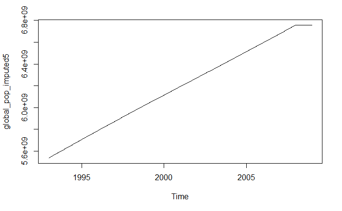

```r
global_pop_imputed5 = as.ts(na_seadec(gpi), start = 1993, frequency = 36)
plot(global_pop_imputed5)
```

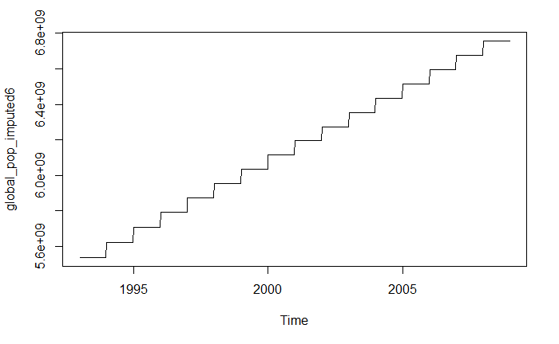

```r
global_pop_imputed6 = as.ts(na_locf(gpi), start = 1993, frequency = 36)
plot(global_pop_imputed6)
```

global population is nearly linear, hmmm questionable value but oh well

###ice area??? Yearly Area of Polar Ice Caps (in 10^6 km^2) from [National Snow and Ice Data Center](https://nsidc.org/arcticseaicenews/sea-ice-tools/), 1981-2010

```r
ice0 <- read.csv("D:/SMU/DS 6373 Time Series/N_seaice_extent_climatology_1981-2010_v3.0.csv")
#https://nsidc.org/arcticseaicenews/sea-ice-tools/
```

[output not shown]

[output cut: 81 more lines]

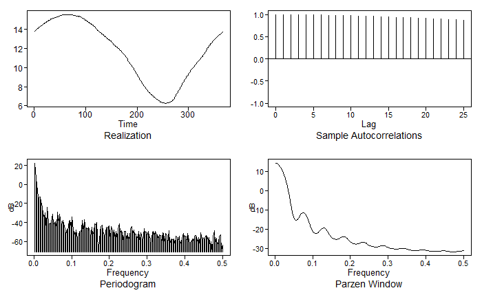

```r
ice <- ts(ice0$Average.Extent, start = 1981, frequency =  12)
plotts.sample.wge(ice)
```

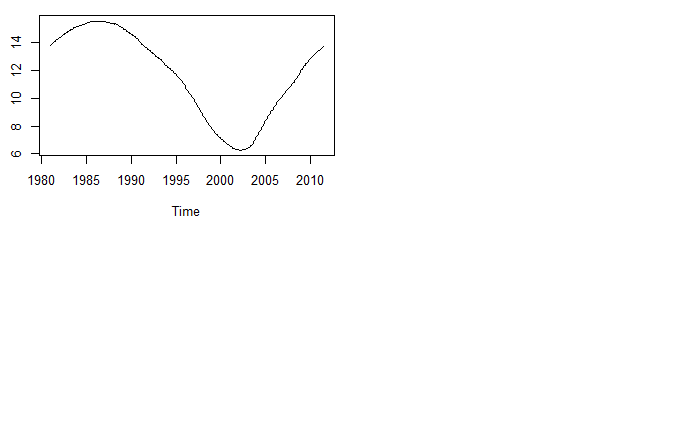

```r
plot(ice)
```

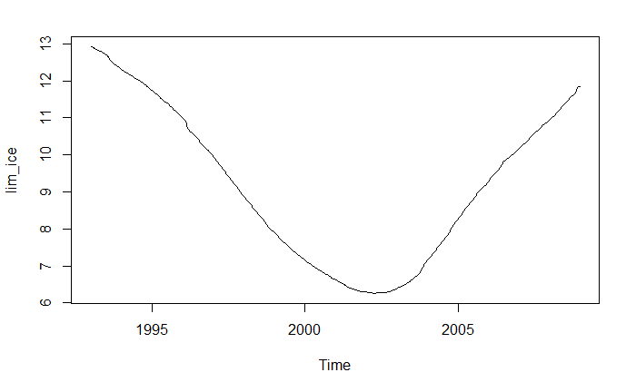

```r
ice_monthly_trim <- ice[144:336]
trimonthly_imputation= vector()
year = seq(1, (length(ice_monthly_trim)-1), 1)
for(q in year)
{
  trimonthly_imputation <- append(trimonthly_imputation, ice_monthly_trim[q])
  #print(epc[q])
  trimonthly_imputation <- append(trimonthly_imputation, rep(NA, 2))
}

lim_ice = ts(trimonthly_imputation, start = 1993, frequency = 36)
lim_ice = as.ts(na_interpolation(lim_ice, option = 'linear'), start = 1993, frequency = 36)
plot(lim_ice)
```

```r
#multivariate ts annual
pop_a = as.numeric(as.character(global_pop[34:49]))
erg_a = as.numeric(as.character(ye[14:29]))
epc = ((erg_a/pop_a)*10^15)
epc #as mean BTU consumed per capita, from 1993:2008
```

```
 [1] 370500857 443568972 461495359 476991941 502803323 510511623 526238687 547496430
 [9] 563890920 574955734 598487784 609883599 639529246 651235272 644931219 655234378
```

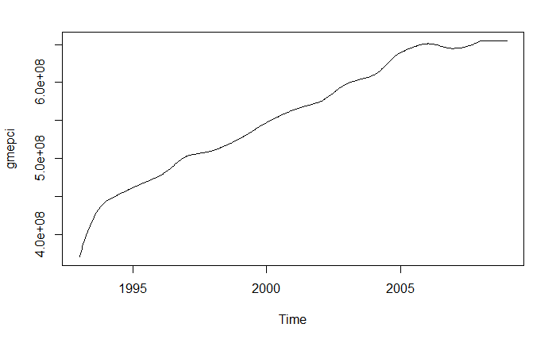

```r
trimonthly_imputation = vector()
year = seq(1, 16, 1) #limited overlap range for multivariate merge
for(q in year)
{
  trimonthly_imputation <- append(trimonthly_imputation, epc[q])
  #print(epc[q])
  trimonthly_imputation <- append(trimonthly_imputation, rep(NA, 35))
}

ergi = ts(trimonthly_imputation, start = 1993, frequency = 36)

#global mean energy per capita, imputed
gmepci = as.ts(na_interpolation(ergi, option = 'stine'), start = 1993, frequency = 36)
plot(gmepci)
```

#### context

1 KwH = 3412.14 BTU 1 KwH would power an 800 watt microwave for 1.25 hrs, or 75 minutes. Average yearly BTU per person in 1993 = 370500857 BTU /3412.14 BTU/KwH = 108583.0555 KwH *1.25= 135728.8194 hours of 800W microwave use /24/365= running 15.49 800W microwaves 24/7 all year in 1993.

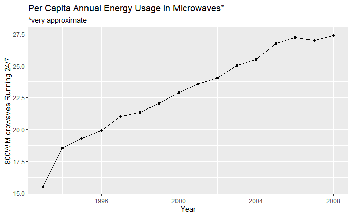

```r
conversion_rate =(((epc/3412.14)*1.25)/24/365)
microwaves_per_year <- ts(conversion_rate, start = 1993, frequency = 1)
vm <- ggplot(data = microwaves_per_year, aes(x = seq(1993, 2008, 1), y = as.data.frame(microwaves_per_year)$x)) +
  geom_line()+
  geom_point()
vm + labs(title = "Per Capita Annual Energy Usage in Microwaves*", subtitle = "*very approximate", x = "Year", y = "800W Microwaves Running 24/7")
```

```r
NA
```

by 2008, the theoretical average person is running the equivalent of 27 800W microwaves all year

```r
#multivariate ts imputed
lim_sea = sea$GMSL.variation.GIA[1:576]
lim_erg = imputed_erg1
lim_pop = global_pop_imputed3
lim_epp = gmepci #erg per pop
#lim_ice #10^6 km^2 of polar ice
#oops looks like sea data isn't exactly 36 per year, some error can be attributed to skew between the actual dates of the sea level measurements and the imputed data on the rest of the variables
#....maybe...
#create dummy vars in the sea data for round yearly to match erg and pop
#get spacing on the sea data to match pattern in erg/pop
#impute the years on the sea data
#impute everything but years on pop/erg data
#????
#... get time matched datasets?
```

now that we have all the parts for additional data to use as variables… hopefully

#Section B: VAR model

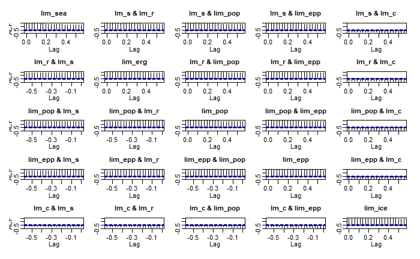

```r
library(vars)

mv1 <- cbind(lim_sea, lim_erg, lim_pop, lim_epp, lim_ice)

acf(mv1)
```

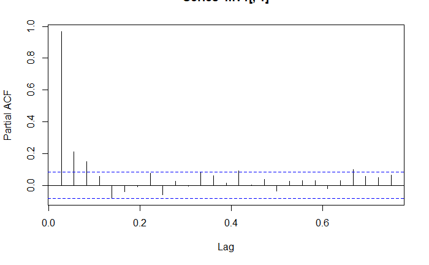

```r
pacf(mv1[, 1])
```

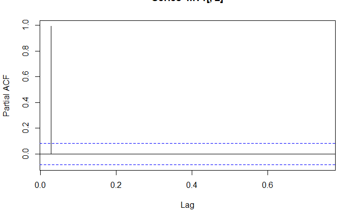

```r
pacf(mv1[, 2])
```

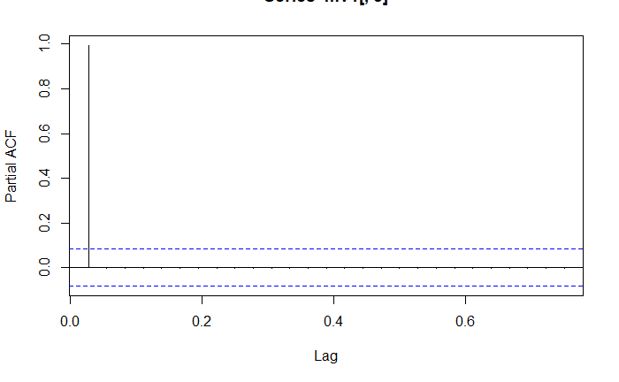

```r
pacf(mv1[, 3])
```

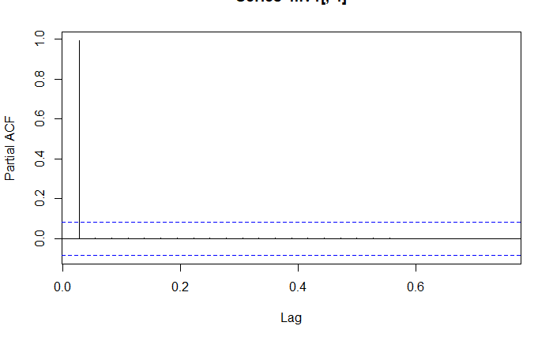

```r
pacf(mv1[, 4])
```